# GEOG 5680 6680 15c Making better maps with **tmap**

Simon Brewer Geography Department University of Utah

May 12, 2020

# Introduction

In this lab we’ll introduce the add-on package **tmap**, which can be used to produce much nicer maps than the default mapping functions in R. Before starting the lab, make sure this is installed.

Remember to use RStudio’s script editor (top left panel) to enter your commands and then copy-paste these to the console when you are ready. This will keep a copy of the commands that you can save and return to.

Before starting, remember to create a working directory (e.g. `module15`). Next download the files for today’s lab from the Canvas page and move them to this directory (unzip the compressed files). You’ll need the following files:

- Climate dataset for Western North America: *WNAclimate.csv*
- New York state polygon data in a shapefile: *NY_Data.zip*
- A shapefile of country borders: *ne_50m_admin_0_countries.zip*
- A NetCDF file of global monthly air temperature: *air.mon.ltm.nc*

Then start RStudio, and change your working directory from the [Session] menu > [Set working directory] > [Choose directory…]. Remember to check that R can see the files by running the `list.files()` command.

# The **tmap** package

**tmap** works in a very similar way to **ggplot2**, by building a series of layers and map geometries and elements. In general, we start by using `tm_shape()` to identify the spatial object to be used, and add geometries are added, including filled polygons, borders and symbols. Finally, we can add legends, scale bars, etc.

```r
library(tmap)
```

## Example 1: Syracuse data

For the first example, we’ll make some maps using the subset of the `NY8` shapefile for Syracuse (we used this in a previous module). Start by loading the packages we need (**rgdal** to read the data, and **tmap** to plot it):

```r
library(tmap)
library(rgdal)
```

Next load the `NY8` data, and subset Syracuse. We’ll also make a quick map with the default mapping function as a reference:

```r
NY8 <- readOGR("NY_data/NY8_utm18.shp")
```

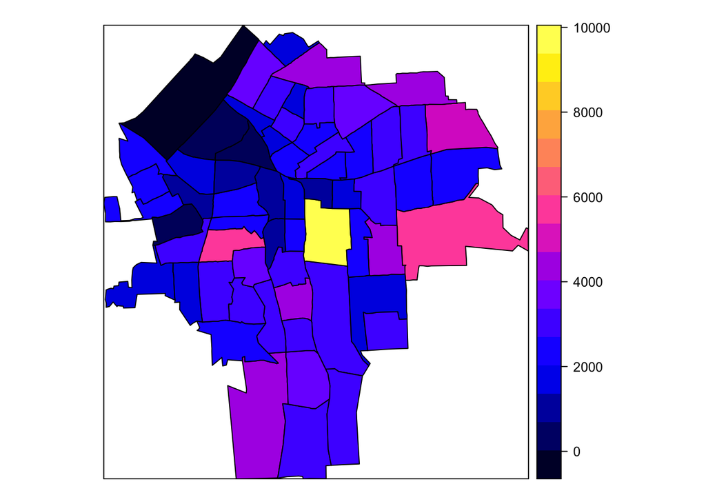

```r
Syracuse <- NY8[NY8$AREANAME == "Syracuse city", ]
spplot(Syracuse, "POP8")
```

Now let’s do the same things with **tmap**. First, let’s make a simple map showing the polygon outlines using `tm_borders()`:

```r
tm_shape(Syracuse) + tm_borders()
```

The function `tm_fill()` will then fill these using one of the variables in the Syracuse data set (POP8). Note that this automatically adds a legend within the frame of the figure:

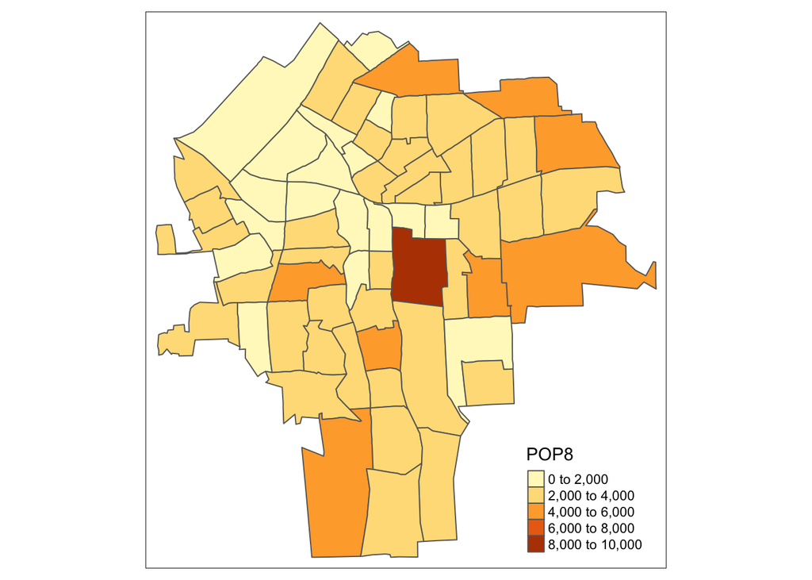

```r
tm_shape(Syracuse) + tm_borders() + tm_fill("POP8")
```

The color scale can be changed by setting the `palette` argument in `tm_fill()`. This includes the ColorBrewer scales described in the previous module, and the algorithm used to define the intervals. For example, to use the ‘Greens’ palette with percentile breaks:

```r
tm_shape(Syracuse) + tm_borders() +
  tm_fill("POP8", palette = "Greens", style = "quantile")
```

If you want to see the full set of palettes that you can use, install the **tmaptools** package and run the following code (you may also need to install **shinyjs**):

```r
tmaptools::palette_explorer()
```

Other map elements can be added. Here we add a longitude/latitude graticule with `tm_graticules()`, a north arrow and a line of text with the date the map was made.

```r
tm_shape(Syracuse) + tm_graticules(col = "lightgray") + tm_borders() +
  tm_fill("POP8", palette = "Greens", style = "quantile") +
  tm_compass(position = c("left", "bottom")) +
  tm_credits("2019-10-19", position = c("right", "top"))
```

## Interactive maps

**tmap** also has a function to produce a simple, interactive map. This is done by changing the mode of operation from `plot` to `view`. The following code set the mode to interactive, makes a simple plot of the Syracuse data, and resets the mode to static plots. Note that these plots will be interactive in RStudio, and can also be embedded in the html files produced in R Markdown. At the end we reset the view back to static plots. Note that you can use this interactive function with any data with latitude/longitude coordinates.

```r
tmap_mode("view")
names(Syracuse)
tm_shape(Syracuse) + tm_borders() + tm_fill("Cases", palette = "Greens")
tmap_mode("plot")
```

## Example 2

We’ll next make some maps with the Western North American site data. We’ll first need to read the data in:

```r
wnaclim <- read.csv("WNAclimate.csv")
str(wnaclim)
```

```
## 'data.frame':    2012 obs. of  8 variables:
##  $ WNASEQ  : int  1 2 3 4 5 6 7 8 9 10 ...
##  $ LONDD   : num  -108 -105 -103 -110 -114 ...
##  $ LATDD   : num  50.9 55.3 41.7 44.3 59.2 ...
##  $ ELEV    : int  686 369 1163 2362 880 900 1100 1480 651 725 ...
##  $ totsnopt: num  78.8 145.4 42.7 255.1 164.9 ...
##  $ annp    : int  326 499 450 489 412 451 492 606 443 455 ...
##  $ Jan_Tmp : num  -13.9 -21.3 -4.2 -10.9 -23.9 -17.5 -18.8 -11 -22.4 -23.5 ...
##  $ Jul_Tmp : num  18.8 16.8 23.3 14.1 14.4 13.8 13.2 12.8 15.3 15.4 ...
```

Now let’s convert this to a Spatial* object (a points data frame):

```r
llCRS <- CRS("+proj=longlat +ellps=WGS84")
wnaclim.spdf <- SpatialPointsDataFrame(cbind(wnaclim$LONDD,
                                             wnaclim$LATDD),
                                       wnaclim, proj4string=llCRS)
```

Individual symbols can be plotted on a color scale using `tm_symbols`.

```r
tm_shape(wnaclim.spdf) + tm_symbols(col="Jan_Tmp")
```

This takes the same arguments as `tm_fill()` for the color palette. We’ll use a red to blue color scale from RColorBrewer. The minus sign before the palette name reverses the order of the colors. As there is a large amount of overlap between the sites, we also add an alpha level to make the symbols transparent.

```r
tm_shape(wnaclim.spdf) +
  tm_symbols(col="Jan_Tmp", alpha = 0.5, palette = "-RdBu")
```

Next, load the Natural Earth shapefile of country boundaries.

```r
countries <- readOGR("ne_50m_admin_0_countries/ne_50m_admin_0_countries.shp")
```

We can now add this to our existing plot. Note that as this is a different spatial object, we have to use `tm_shape()` a second time to reference this, then use `tm_borders()` to add the lines.

```r
tm_shape(wnaclim.spdf) +
  tm_symbols(col="Jan_Tmp", alpha = 0.75, palette = "-RdBu") +
  tm_shape(countries) + tm_borders(col="gray")
```

We can use `tm_style()` to alter the appearance of the map:

```r
tm_shape(wnaclim.spdf) +
  tm_symbols(col="Jan_Tmp", alpha = 0.75, palette = "-RdBu", size = 0.5) +
  tm_shape(countries) + tm_borders(col="gray") + tm_style("cobalt")
```

Like **ggplot2**, the figures that are made can be saved as R objects. Here we make two maps (January and July temperature) and save them as `tm1` and `tm2`

```r
tm1 <- tm_shape(wnaclim.spdf) +
  tm_symbols(col="Jan_Tmp", alpha = 0.75, palette = "-RdBu", size = 0.5) +
  tm_shape(countries) + tm_borders(col="gray") + tm_style("classic")
tm2 <- tm_shape(wnaclim.spdf) +
  tm_symbols(col="Jul_Tmp", alpha = 0.75, palette = "-RdBu", size = 0.5) +
  tm_shape(countries) + tm_borders(col="gray") + tm_style("classic")
```

We can now use `tm_arrange()` to make a single figure with the two maps:

```r
tmap_arrange(tm1, tm2)
```

```
## Variable(s) "Jan_Tmp" contains positive and negative values, so midpoint is set to 0. Set midpoint = NA to show the full spectrum of the color palette.
## Variable(s) "Jan_Tmp" contains positive and negative values, so midpoint is set to 0. Set midpoint = NA to show the full spectrum of the color palette.
```

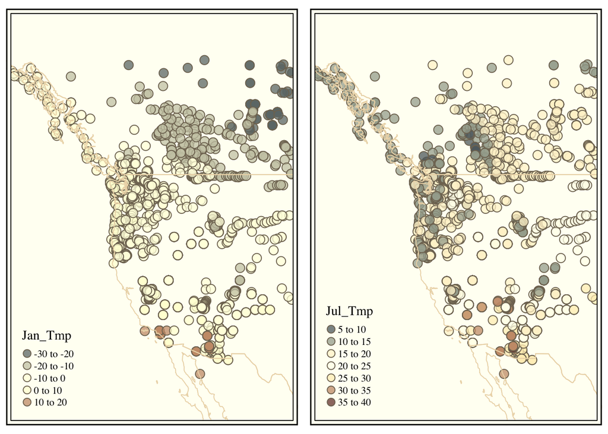

## Example 3

In the final example, we’ll make figures using the global air temperature dataset. Start by reading the data using the **raster** package:

```r
library(raster)
r = raster("air.mon.ltm.nc", varname="air")
r = rotate(r)
names(r)
```

```
## [1] "Monthly.Long.Term.Mean.Air.Temperature.at.sigma.level.0.995"
```

The variable name in our raster layer is quite long and complex, so to reduce the amount of typing in these examples, we’ll change ti to something simpler

```r
names(r) <- "jan_tmp"
```

Now let’s make a plot using `tm_raster()`, which again takes similar options for color palettes. We’ll also add the country borders. Note that there is also a function `tm_rgb()` that allows you to plot multi-band images.

```r
tm_shape(r) +
  tm_raster("jan_tmp", style="fisher", palette="-RdBu") +
  tm_shape(countries) + tm_borders()
```

This throws an error about the projections. We’ll simply set the projection of the raster `r` using the projection from the `countries` object

```r
proj4string(r) <- proj4string(countries)
```

And now remake the figure

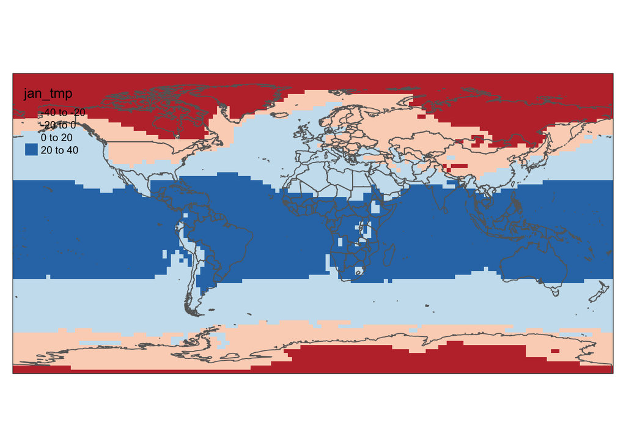

```r
tm_shape(r) +
  tm_raster("jan_tmp", palette="RdBu") +
  tm_shape(countries) + tm_borders()
```

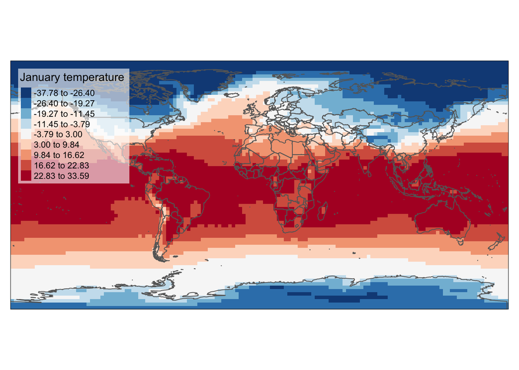

```r
tm_shape(r) +
  tm_raster("jan_tmp", style="fisher", palette="-RdBu", n = 9, title = "January temperature") +
  tm_shape(countries) + tm_borders() +
  tm_layout(legend.bg.color = "white", legend.bg.alpha = 0.6)
```

Alternatively, we can do this a little by moving the color legend outside of the plotting area. We’ll increase the number of color classes to 9, and add a histogram showing the frequency of different values.

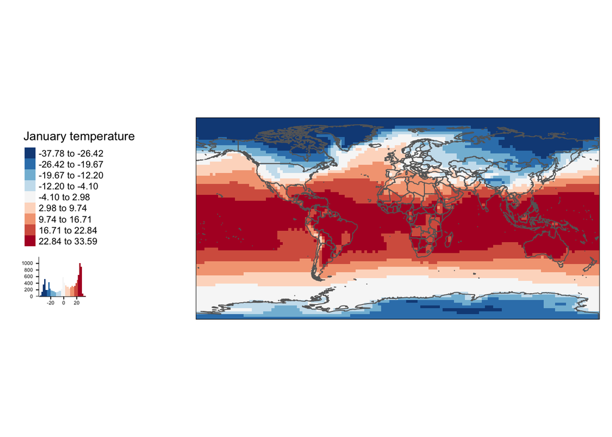

```r
tm_shape(r) +
  tm_raster("jan_tmp", style="fisher", palette="-RdBu", legend.hist = TRUE,
            n = 9, title = "January temperature") +
  tm_shape(countries) + tm_borders() + tm_layout(legend.outside = TRUE,
                                                 legend.outside.position = "left")
```

# Exercise

There is no additional exercise for today, but you need to submit your R script or (preferably) a Markdown document with the code examples from the lab